# HCC formula comparison — HMC + Pathfinder

Production, strong HMC, and Pathfinder RE variants on four TIMES biomarkers

Author

Affiliation

Chen Zhan

SAiGENCI, The University of Adelaide

Published

22 Jul 2026

Abstract

Gene-wise comparison of six V1_nk tissue-formula / inference variants for the TIMES HCC biomarkers (SPON2, ZFP36L2, ZFP36, VIM): production HMC (RE rich), three strong-HMC simple-shape refits (correlated RE, interaction, uncorrelated RE), and two CPU Pathfinder dense fits (original RE and split-ethnicity RE). For each gene × variant we report convergence-style diagnostics and the comprehensive healthy liver baseline mean and SD of log(μ). Pathfinder cells use a draw-count target matched to strong HMC (6000). For non-production strong HMC fits we also trace how max R̂, baseline μ, and baseline SD change as post-warmup draws accumulate, and report a minimum-draw stability threshold. Rendering reads cached fits only; set `refresh_diagnostics: true` after new fits land (also refreshes the HMC draw-stability cache).

# Motivation

We compare **six** formula / inference settings on the same four TIMES genes and the same comprehensive healthy liver baseline estimand:

1. **Convergence / reliability** — HMC R̂, divergences, treedepth, ESS; for Pathfinder, draw count and finite baseline summaries (no multi-chain HMC gates)
2. **Baseline mean** — posterior mean of comprehensive liver `log(μ)`
3. **Baseline SD** — posterior uncertainty of that estimand

| Label | Counts formula | Shape | Inference |
| --- | --- | --- | --- |
| Production | correlated RE `(\\| tissue)` | rich | HMC (atlas) |
| RE HMC | correlated RE `(\\| tissue)` | simple | HMC 4×1500/3000 |
| Interaction HMC | fixed tissue × covariate | simple | HMC 4×1500/3000 |
| RE uncorrelated HMC | uncorrelated RE `(\\|\\| tissue)` | simple | HMC 4×1500/3000 |
| Pathfinder RE | correlated RE (same as RE HMC) | simple | Pathfinder CPU dense |
| Pathfinder RE-split | `(1+age×sex\\|tissue) + (0+ethnicity\\|tissue)` | simple | Pathfinder CPU dense |

Pathfinder settings follow the successful pilot (CPU, dense, not OpenCL): `num_paths = 50`, `single_path_draws = 120` → **6000** draws targeted to match strong HMC post-warmup draws (`4 × 1500`).

# Library setup

```r
suppressPackageStartupMessages({
  library(tibble)
  library(tidyr)
  library(dplyr)
  library(readr)
  library(ggplot2)
  library(forcats)
  library(scales)
  library(glue)
  library(stringr)
  library(posterior)
  library(brms)
  library(targets)
})

source(file.path(params$case_dir, "R", "re_vs_interaction_helpers.R"))
source(file.path(params$case_dir, "R", "fit_convergence_helpers.R"))

theme_set(theme_minimal(base_size = 11))

formula_levels <- c(
  "production", "re", "interaction", "re_uncorrelated",
  "pathfinder_re", "pathfinder_re_split"
)
formula_labels <- c(
  production = "Production (RE rich)",
  re = "RE HMC (simple)",
  interaction = "Interaction HMC (simple)",
  re_uncorrelated = "RE uncorrelated HMC (simple)",
  pathfinder_re = "Pathfinder RE (simple)",
  pathfinder_re_split = "Pathfinder RE-split (simple)"
)
formula_colours <- c(
  production = "#7A7A7A",
  re = "#4DBBD5",
  interaction = "#E64B35",
  re_uncorrelated = "#3C5488",
  pathfinder_re = "#00A087",
  pathfinder_re_split = "#91D1C2"
)
gate_colours <- c(PASS = "#2D8B57", WARN = "#E08A2E", FAIL = "#C23B4A")
fill_vals <- setNames(unname(formula_colours), unname(formula_labels))
```

# Fit inventory

Expected grid: **4 genes × 6 formulas = 24 cells**.

```r
meta <- strong_formula_inventory(
  strong_out_dir = params$strong_out_dir,
  case_dir = params$case_dir,
  model_store_root = params$model_store_root,
  target_cell_type = params$target_cell_type
)

meta$inventory |>
  mutate(
    formula = factor(recode(model, !!!formula_labels), levels = unname(formula_labels)),
    status = if_else(available, source, "MISSING")
  ) |>
  select(gene, formula, role, shape_variant, status, file_name) |>
  arrange(gene, formula)
```

| gene | formula | role | shape_variant | status | file_name |
| --- | --- | --- | --- | --- | --- |
| SPON2 | Production (RE rich) | production | rich | production_store | NA |
| SPON2 | RE HMC (simple) | strong | simple | local_rds | fit_re_SPON2.rds |
| SPON2 | Interaction HMC (simple) | strong | simple | local_rds | fit_interaction_SPON2.rds |
| SPON2 | RE uncorrelated HMC (simple) | strong | simple | local_rds | fit_re_uncorrelated_SPON2.rds |
| SPON2 | Pathfinder RE (simple) | pathfinder | simple | local_rds | fit_pathfinder_re_SPON2.rds |
| SPON2 | Pathfinder RE-split (simple) | pathfinder | simple | local_rds | fit_pathfinder_re_split_SPON2.rds |
| VIM | Production (RE rich) | production | rich | production_store | NA |
| VIM | RE HMC (simple) | strong | simple | local_rds | fit_re_VIM.rds |
| VIM | Interaction HMC (simple) | strong | simple | local_rds | fit_interaction_VIM.rds |
| VIM | RE uncorrelated HMC (simple) | strong | simple | local_rds | fit_re_uncorrelated_VIM.rds |

[output cut: 14 more lines]

```r
n_ok <- sum(meta$inventory$available)
n_tot <- nrow(meta$inventory)
n_pf <- meta$inventory |>
  filter(str_detect(model, "^pathfinder"), available) |>
  nrow()
if (n_ok < n_tot) {
  miss <- meta$inventory |> filter(!available)
  cat(glue(
    "**{n_ok}/{n_tot}** fits available ({n_pf} Pathfinder). Missing: ",
    "{paste(miss$gene, miss$model, sep = '/', collapse = ', ')}."
  ))
} else {
  cat(glue("All **{n_tot}** fits are available, including **{n_pf}** Pathfinder cells."))
}
```

All **24** fits are available, including **8** Pathfinder cells.

# Diagnostics

**HMC gates** (production + strong HMC cells):

| Gate | PASS rule |
| --- | --- |
| R̂ | `max_rhat ≤ 1.05` |
| Divergences | `< 1%` of post-warmup transitions |
| Treedepth | `< 10%` hit `max_treedepth` |
| Baseline chains | range of chain-mean liver `log(μ)` `< 1` |

**Pathfinder gates** (approximate; not multi-chain HMC): finite baseline mean/SD and `n_draws ≥ 100`. R̂ / divergence / treedepth columns are shown when available but are **not** used to FAIL Pathfinder cells.

`FAIL` (HMC only) = `max_rhat > 1.5` or `≥ 50%` divergences; else soft → `WARN`.

```r
diag_path <- params$diagnostics_csv
draws_path <- params$draws_rds

# Refresh if forced, missing, or inventory has models absent from the cache
# (e.g. Pathfinder fits landed after the last diagnostics run).
need_refresh <- isTRUE(params$refresh_diagnostics) || !file.exists(diag_path)
if (!need_refresh && file.exists(diag_path)) {
  old <- read_csv(diag_path, show_col_types = FALSE)
  avail_models <- meta$inventory |>
    filter(available) |>
    distinct(gene, model)
  cached <- old |> distinct(gene, model)
  need_refresh <- nrow(
    avail_models |> anti_join(cached, by = c("gene", "model"))
  ) > 0
}

if (need_refresh) {
  message("Refreshing diagnostics (includes Pathfinder if present) ...")
  diag_bundle <- diagnose_strong_formula_fits(
    strong_out_dir = params$strong_out_dir,
    case_dir = params$case_dir,
    model_store_root = params$model_store_root,
    target_cell_type = params$target_cell_type,
    compute_baseline = TRUE,
    n_baseline_draws = params$n_baseline_draws,
    cache_csv = diag_path
  )
  diag <- diag_bundle$diagnostics
  # Force draws refresh whenever diagnostics refresh
  if (file.exists(draws_path)) file.remove(draws_path)
} else {
  diag <- read_csv(diag_path, show_col_types = FALSE)
}

diag_view <- diag |>
  mutate(
    formula = factor(
      recode(model, !!!formula_labels),
      levels = unname(formula_labels)
    ),
    is_pathfinder = coalesce(is_pathfinder, str_detect(model, "^pathfinder")),
    engine = if_else(is_pathfinder, "Pathfinder", "HMC"),
    gate = case_when(
      gate_pass ~ "PASS",
      is_pathfinder ~ "WARN",
      max_rhat > 1.5 | pct_divergent >= 50 ~ "FAIL",
      TRUE ~ "WARN"
    ),
    gate = factor(gate, levels = c("PASS", "WARN", "FAIL")),
    settings = if_else(
      is_pathfinder,
      glue("pathfinder; n_draws={coalesce(n_draws, post_warmup_per_chain)}"),
      glue("{chains}×{warmup}/{iter}; δ={adapt_delta}; td={max_treedepth}")
    )
  )
```

## Full table (convergence + baseline)

```r
diag_view |>
  transmute(
    gene,
    formula,
    engine,
    source,
    settings,
    max_rhat = round(max_rhat, 3),
    n_rhat_gt_1_1,
    pct_divergent = round(pct_divergent, 2),
    pct_max_treedepth = round(pct_max_treedepth, 1),
    min_ess_bulk = round(min_ess_bulk, 0),
    n_draws,
    baseline_mean = round(baseline_mean, 3),
    baseline_sd = round(baseline_sd, 3),
    chain_mean_range = round(baseline_chain_mean_range, 3),
    gate
  ) |>
  arrange(gene, formula)
```

| gene | formula | engine | source | settings | max_rhat | n_rhat_gt_1_1 | pct_divergent | pct_max_treedepth | min_ess_bulk | n_draws | baseline_mean | baseline_sd | chain_mean_range | gate |
| --- | --- | --- | --- | --- | --- | --- | --- | --- | --- | --- | --- | --- | --- | --- |
| SPON2 | Production (RE rich) | HMC | production_store | 2×400/600; δ=NA; td=NA | 1.108 | 1 | 8.00 | NA | 4899 | 400 | 7.065 | 1.030 | 0.050 | WARN |
| SPON2 | RE HMC (simple) | HMC | local_rds | 4×1500/3000; δ=0.95; td=12 | 1.007 | 0 | 1.57 | 24.3 | 4837 | 6000 | 7.036 | 1.069 | NA | WARN |
| SPON2 | Interaction HMC (simple) | HMC | local_rds | 4×1500/3000; δ=0.95; td=12 | 1.013 | 0 | 1.25 | 0.3 | 8146 | 6000 | 6.270 | 2.359 | NA | WARN |
| SPON2 | RE uncorrelated HMC (simple) | HMC | local_rds | 4×1500/3000; δ=0.95; td=12 | 1.005 | 0 | 1.28 | 0.0 | 2877 | 6000 | 7.045 | 1.180 | NA | WARN |
| SPON2 | Pathfinder RE (simple) | Pathfinder | local_rds | pathfinder; n_draws=2280 | 1.534 | 250 | NA | NA | 3838 | 2280 | 7.630 | 0.384 | NA | PASS |
| SPON2 | Pathfinder RE-split (simple) | Pathfinder | local_rds | pathfinder; n_draws=2880 | 1.605 | 190 | NA | NA | 3567 | 2880 | 7.556 | 0.407 | NA | PASS |
| VIM | Production (RE rich) | HMC | production_store | 2×400/600; δ=NA; td=NA | 1.293 | 46 | 28.00 | NA | 4318 | 400 | 6.348 | 1.490 | 0.300 | WARN |
| VIM | RE HMC (simple) | HMC | local_rds | 4×1500/3000; δ=0.95; td=12 | 1.006 | 0 | 0.43 | 50.0 | 4513 | 6000 | 6.201 | 1.411 | NA | WARN |
| VIM | Interaction HMC (simple) | HMC | local_rds | 4×1500/3000; δ=0.95; td=12 | 1.013 | 0 | 2.92 | 0.1 | 9627 | 6000 | 5.746 | 2.599 | NA | WARN |
| VIM | RE uncorrelated HMC (simple) | HMC | local_rds | 4×1500/3000; δ=0.95; td=12 | 1.004 | 0 | 1.87 | 0.0 | 2649 | 6000 | 6.344 | 1.543 | NA | WARN |

[output cut: 14 more lines]

## Gate summary by formula

```r
diag_view |>
  count(formula, engine, gate) |>
  pivot_wider(names_from = gate, values_from = n, values_fill = 0) |>
  arrange(formula)
```

| formula | engine | WARN | FAIL | PASS |
| --- | --- | --- | --- | --- |
| Production (RE rich) | HMC | 4 | 0 | 0 |
| RE HMC (simple) | HMC | 4 | 0 | 0 |
| Interaction HMC (simple) | HMC | 4 | 0 | 0 |
| RE uncorrelated HMC (simple) | HMC | 2 | 2 | 0 |
| Pathfinder RE (simple) | Pathfinder | 0 | 0 | 4 |
| Pathfinder RE-split (simple) | Pathfinder | 0 | 0 | 4 |

# 1. Convergence

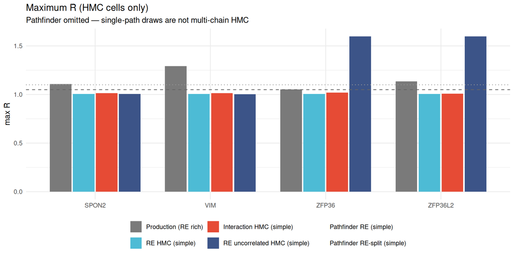

```r
diag_hmc <- diag_view |> filter(!is_pathfinder)

ggplot(diag_hmc, aes(x = gene, y = max_rhat, fill = formula)) +
  geom_col(position = position_dodge(width = 0.8), width = 0.75) +
  geom_hline(yintercept = 1.05, linetype = 2, colour = "grey40") +
  geom_hline(yintercept = 1.1, linetype = 3, colour = "grey60") +
  scale_fill_manual(values = fill_vals, drop = FALSE) +
  labs(
    title = "Maximum R̂ (HMC cells only)",
    subtitle = "Pathfinder omitted — single-path draws are not multi-chain HMC",
    x = NULL, y = "max R̂", fill = NULL
  ) +
  theme(legend.position = "bottom")
```

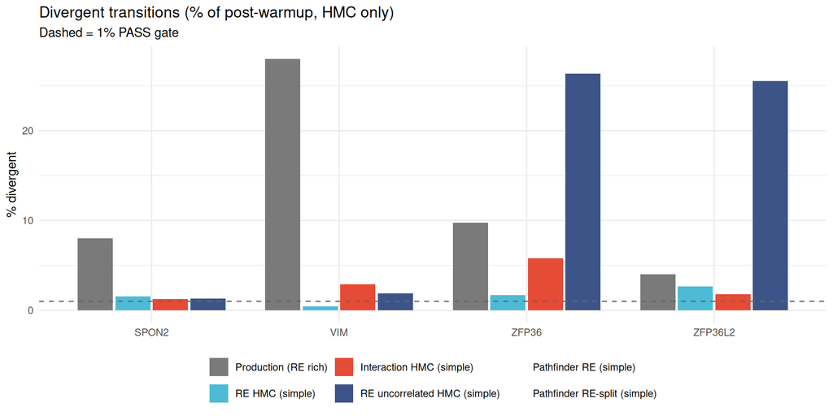

```r
ggplot(diag_hmc, aes(x = gene, y = pct_divergent, fill = formula)) +
  geom_col(position = position_dodge(width = 0.8), width = 0.75) +
  geom_hline(yintercept = 1, linetype = 2, colour = "grey40") +
  scale_fill_manual(values = fill_vals, drop = FALSE) +
  labs(
    title = "Divergent transitions (% of post-warmup, HMC only)",
    subtitle = "Dashed = 1% PASS gate",
    x = NULL, y = "% divergent", fill = NULL
  ) +
  theme(legend.position = "bottom")
```

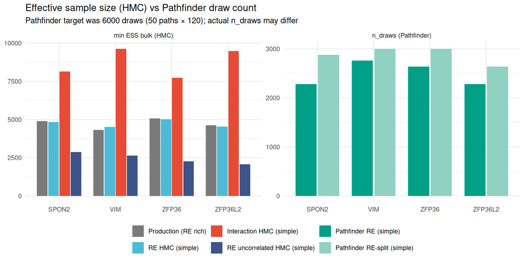

```r
# HMC: min bulk ESS; Pathfinder: reported n_draws (approximation quality proxy)
ess_plot <- diag_view |>
  mutate(
    metric = if_else(is_pathfinder, as.numeric(n_draws), as.numeric(min_ess_bulk)),
    metric_label = if_else(is_pathfinder, "n_draws (Pathfinder)", "min ESS bulk (HMC)")
  )

ggplot(ess_plot, aes(x = gene, y = metric, fill = formula)) +
  geom_col(position = position_dodge(width = 0.8), width = 0.75) +
  facet_wrap(~ metric_label, scales = "free_y") +
  scale_fill_manual(values = fill_vals, drop = FALSE) +
  labs(
    title = "Effective sample size (HMC) vs Pathfinder draw count",
    subtitle = "Pathfinder target was 6000 draws (50 paths × 120); actual n_draws may differ",
    x = NULL, y = NULL, fill = NULL
  ) +
  theme(legend.position = "bottom")
```

```r
gate_by_formula <- diag_view |>
  group_by(formula, engine) |>
  summarise(
    n = n(),
    n_pass = sum(gate == "PASS"),
    n_warn = sum(gate == "WARN"),
    n_fail = sum(gate == "FAIL"),
    median_rhat = median(max_rhat, na.rm = TRUE),
    median_n_draws = median(n_draws, na.rm = TRUE),
    .groups = "drop"
  )

worst_hmc <- diag_view |>
  filter(!is_pathfinder) |>
  arrange(desc(max_rhat)) |>
  slice(1)

cat(glue(
  "Among HMC cells, worst max R̂ is **{round(worst_hmc$max_rhat, 3)}** for ",
  "**{worst_hmc$gene} / {worst_hmc$formula}** (gate = {worst_hmc$gate}).\n\n"
))
```

Among HMC cells, worst max R̂ is **1.598** for **ZFP36 / RE uncorrelated HMC (simple)** (gate = FAIL).

```r
knitr::kable(gate_by_formula |> mutate(across(where(is.numeric), ~ round(.x, 3))))
```

| formula | engine | n | n_pass | n_warn | n_fail | median_rhat | median_n_draws |
| --- | --- | --- | --- | --- | --- | --- | --- |
| Production (RE rich) | HMC | 4 | 0 | 4 | 0 | 1.121 | 400 |
| RE HMC (simple) | HMC | 4 | 0 | 4 | 0 | 1.006 | 6000 |
| Interaction HMC (simple) | HMC | 4 | 0 | 4 | 0 | 1.013 | 6000 |
| RE uncorrelated HMC (simple) | HMC | 4 | 0 | 2 | 2 | 1.301 | 6000 |
| Pathfinder RE (simple) | Pathfinder | 4 | 4 | 0 | 0 | 1.565 | 2460 |
| Pathfinder RE-split (simple) | Pathfinder | 4 | 4 | 0 | 0 | 1.459 | 2940 |

# 2. Baseline mean (comprehensive liver log μ)

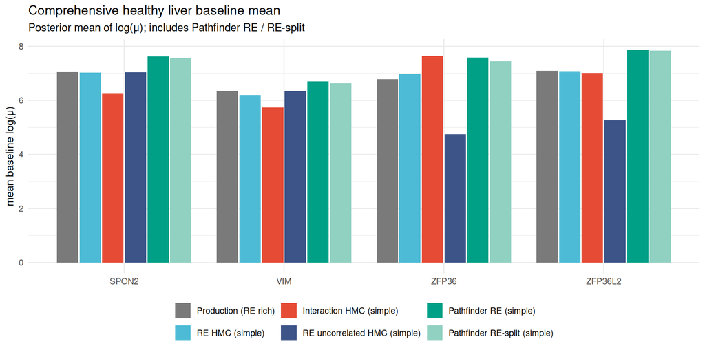

```r
ggplot(diag_view, aes(x = gene, y = baseline_mean, fill = formula)) +
  geom_col(position = position_dodge(width = 0.85), width = 0.8) +
  scale_fill_manual(values = fill_vals, drop = FALSE) +
  labs(
    title = "Comprehensive healthy liver baseline mean",
    subtitle = "Posterior mean of log(μ); includes Pathfinder RE / RE-split",
    x = NULL, y = "mean baseline log(μ)", fill = NULL
  ) +
  theme(legend.position = "bottom")
```

```r
mean_vs_prod <- diag_view |>
  select(gene, model, baseline_mean) |>
  pivot_wider(names_from = model, values_from = baseline_mean) |>
  mutate(
    across(
      any_of(c(
        "re", "interaction", "re_uncorrelated",
        "pathfinder_re", "pathfinder_re_split"
      )),
      ~ .x - production,
      .names = "delta_{.col}"
    )
  )

mean_vs_prod |>
  mutate(across(where(is.numeric), ~ round(.x, 3))) |>
  arrange(gene)
```

| gene | interaction | pathfinder_re | pathfinder_re_split | production | re | re_uncorrelated | delta_re | delta_interaction | delta_re_uncorrelated | delta_pathfinder_re | delta_pathfinder_re_split |
| --- | --- | --- | --- | --- | --- | --- | --- | --- | --- | --- | --- |
| SPON2 | 6.270 | 7.630 | 7.556 | 7.065 | 7.036 | 7.045 | -0.030 | -0.795 | -0.020 | 0.565 | 0.490 |
| VIM | 5.746 | 6.698 | 6.641 | 6.348 | 6.201 | 6.344 | -0.147 | -0.602 | -0.004 | 0.350 | 0.293 |
| ZFP36 | 7.645 | 7.586 | 7.455 | 6.789 | 6.975 | 4.747 | 0.185 | 0.856 | -2.042 | 0.796 | 0.666 |
| ZFP36L2 | 7.009 | 7.873 | 7.837 | 7.096 | 7.080 | 5.260 | -0.016 | -0.087 | -1.837 | 0.777 | 0.741 |

### Pathfinder vs matched HMC RE (same counts formula)

```r
pf_vs_re <- diag_view |>
  filter(model %in% c("re", "pathfinder_re", "pathfinder_re_split")) |>
  select(gene, model, baseline_mean, baseline_sd, gate) |>
  pivot_wider(
    names_from = model,
    values_from = c(baseline_mean, baseline_sd, gate)
  ) |>
  mutate(
    delta_pf_re = baseline_mean_pathfinder_re - baseline_mean_re,
    delta_pf_split = baseline_mean_pathfinder_re_split - baseline_mean_re
  )

pf_vs_re |>
  mutate(across(where(is.numeric), ~ round(.x, 3))) |>
  arrange(gene)
```

| gene | baseline_mean_pathfinder_re | baseline_mean_pathfinder_re_split | baseline_mean_re | baseline_sd_pathfinder_re | baseline_sd_pathfinder_re_split | baseline_sd_re | gate_pathfinder_re | gate_pathfinder_re_split | gate_re | delta_pf_re | delta_pf_split |
| --- | --- | --- | --- | --- | --- | --- | --- | --- | --- | --- | --- |
| SPON2 | 7.630 | 7.556 | 7.036 | 0.384 | 0.407 | 1.069 | PASS | PASS | WARN | 0.595 | 0.520 |
| VIM | 6.698 | 6.641 | 6.201 | 0.586 | 0.690 | 1.411 | PASS | PASS | WARN | 0.497 | 0.440 |
| ZFP36 | 7.586 | 7.455 | 6.975 | 0.433 | 0.454 | 1.535 | PASS | PASS | WARN | 0.611 | 0.481 |
| ZFP36L2 | 7.873 | 7.837 | 7.080 | 0.426 | 0.435 | 1.368 | PASS | PASS | WARN | 0.793 | 0.757 |

# 3. Baseline SD

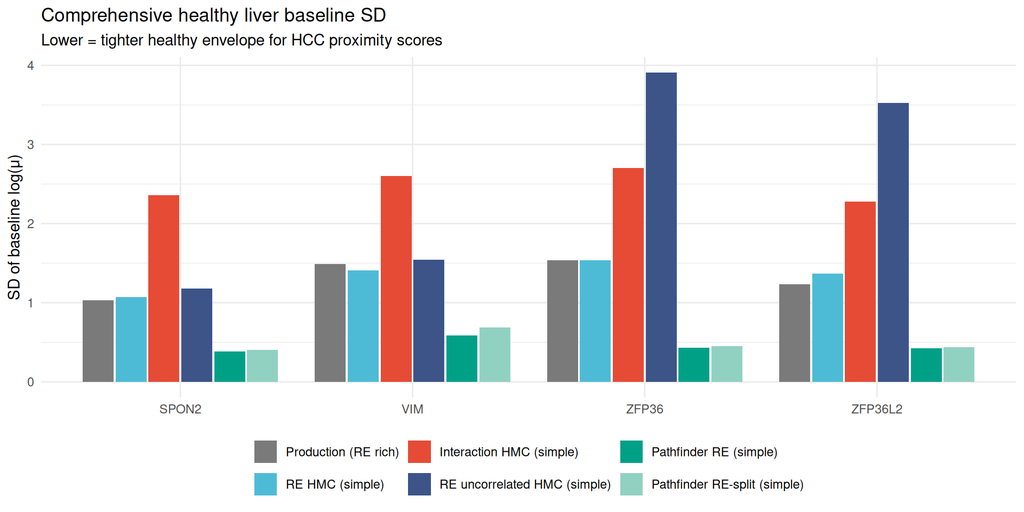

```r
ggplot(diag_view, aes(x = gene, y = baseline_sd, fill = formula)) +
  geom_col(position = position_dodge(width = 0.85), width = 0.8) +
  scale_fill_manual(values = fill_vals, drop = FALSE) +
  labs(
    title = "Comprehensive healthy liver baseline SD",
    subtitle = "Lower = tighter healthy envelope for HCC proximity scores",
    x = NULL, y = "SD of baseline log(μ)", fill = NULL
  ) +
  theme(legend.position = "bottom")
```

```r
sd_vs_prod <- diag_view |>
  select(gene, model, baseline_sd) |>
  pivot_wider(names_from = model, values_from = baseline_sd) |>
  mutate(
    across(
      any_of(c(
        "re", "interaction", "re_uncorrelated",
        "pathfinder_re", "pathfinder_re_split"
      )),
      ~ .x / production,
      .names = "ratio_{.col}"
    )
  )

sd_vs_prod |>
  mutate(across(where(is.numeric), ~ round(.x, 3))) |>
  arrange(gene)
```

| gene | interaction | pathfinder_re | pathfinder_re_split | production | re | re_uncorrelated | ratio_re | ratio_interaction | ratio_re_uncorrelated | ratio_pathfinder_re | ratio_pathfinder_re_split |
| --- | --- | --- | --- | --- | --- | --- | --- | --- | --- | --- | --- |
| SPON2 | 2.359 | 0.384 | 0.407 | 1.030 | 1.069 | 1.180 | 1.038 | 2.291 | 1.146 | 0.373 | 0.395 |
| VIM | 2.599 | 0.586 | 0.690 | 1.490 | 1.411 | 1.543 | 0.947 | 1.744 | 1.035 | 0.393 | 0.463 |
| ZFP36 | 2.703 | 0.433 | 0.454 | 1.538 | 1.535 | 3.910 | 0.998 | 1.757 | 2.542 | 0.282 | 0.295 |
| ZFP36L2 | 2.277 | 0.426 | 0.435 | 1.234 | 1.368 | 3.523 | 1.108 | 1.845 | 2.855 | 0.345 | 0.352 |

```r
narrowest <- diag_view |>
  group_by(gene) |>
  slice_min(baseline_sd, n = 1, with_ties = FALSE) |>
  ungroup()

cat("Narrowest baseline SD per gene:\n\n")
```

Narrowest baseline SD per gene:

```r
knitr::kable(
  narrowest |>
    transmute(gene, formula, engine, baseline_sd = round(baseline_sd, 3), gate)
)
```

| gene | formula | engine | baseline_sd | gate |
| --- | --- | --- | --- | --- |
| SPON2 | Pathfinder RE (simple) | Pathfinder | 0.384 | PASS |
| VIM | Pathfinder RE (simple) | Pathfinder | 0.586 | PASS |
| ZFP36 | Pathfinder RE (simple) | Pathfinder | 0.433 | PASS |
| ZFP36L2 | Pathfinder RE (simple) | Pathfinder | 0.426 | PASS |

# 4. HMC draw stability (non-production)

Production atlas fits are short (typically 2 × 200 post-warmup) and Pathfinder is not multi-chain HMC, so this section uses only the three **strong HMC** variants: RE, interaction, and RE-uncorrelated (4 genes × 3 = 12 fits).

**Method.** For each fit, take the first $k$ post-warmup iterations from every chain ($k$ on a grid up to 1500 → $n_{\mathrm{draws}} = 4k$). At each $k$:

1. **Convergence** — max R̂ over a fixed parameter set (worst + core / liver)
2. **Baseline μ** — mean of comprehensive liver `log(μ)` over those draws
3. **Baseline SD** — SD of the same estimand

**Stability rule** (relative to the full 6000-draw endpoint):

| Metric | Stable when… |
| --- | --- |
| Baseline μ | within `max(0.05, 2% × \|μ_full\|)` of μ_full and stays there |
| Baseline SD | within `max(0.05, 5% × SD_full)` of SD_full and stays there |
| max R̂ | within 0.02 of R̂_full **and** ≤ 1.05, and stays there |

The reported **minimum draws** for a fit is the first $n$ where **all three** criteria hold thereafter (`n_draws_all_stable`).

```r
stab_path <- params$hmc_stability_rds
need_stab <- isTRUE(params$refresh_diagnostics) || !file.exists(stab_path)

if (need_stab) {
  message("Computing HMC cumulative draw-stability curves ...")
  stab <- collect_hmc_draw_stability(
    strong_out_dir = params$strong_out_dir,
    case_dir = params$case_dir,
    model_store_root = params$model_store_root,
    target_cell_type = params$target_cell_type,
    cache_rds = stab_path,
    force = TRUE
  )
} else {
  stab <- readRDS(stab_path)
}

stab_curves <- stab$curves |>
  mutate(
    formula = factor(
      recode(model, !!!formula_labels),
      levels = unname(formula_labels)
    )
  ) |>
  group_by(gene, model) |>
  mutate(
    mean_final = dplyr::last(baseline_mean),
    sd_final = dplyr::last(baseline_sd),
    rhat_final = dplyr::last(max_rhat),
    mean_delta = baseline_mean - mean_final,
    sd_ratio = baseline_sd / sd_final,
    rhat_delta = max_rhat - rhat_final
  ) |>
  ungroup()

stab_thresholds <- stab$thresholds |>
  mutate(
    formula = factor(
      recode(model, !!!formula_labels),
      levels = unname(formula_labels)
    )
  )
```

## Stability thresholds (minimum draws)

```r
stab_thresholds |>
  transmute(
    gene,
    formula,
    n_draws_full,
    max_rhat_full = round(max_rhat_full, 3),
    baseline_mean_full = round(baseline_mean_full, 3),
    baseline_sd_full = round(baseline_sd_full, 3),
    n_draws_rhat_stable,
    n_draws_mean_stable,
    n_draws_sd_stable,
    n_draws_all_stable
  ) |>
  arrange(gene, formula)
```

| gene | formula | n_draws_full | max_rhat_full | baseline_mean_full | baseline_sd_full | n_draws_rhat_stable | n_draws_mean_stable | n_draws_sd_stable | n_draws_all_stable |
| --- | --- | --- | --- | --- | --- | --- | --- | --- | --- |
| SPON2 | RE HMC (simple) | 6000 | 1.047 | 7.046 | 1.087 | 2400 | 100 | 200 | 2400 |
| SPON2 | Interaction HMC (simple) | 6000 | 1.017 | 6.269 | 2.539 | 100 | 600 | 2400 | 2400 |
| SPON2 | RE uncorrelated HMC (simple) | 6000 | 1.057 | 7.039 | 1.117 | NA | 100 | 400 | NA |
| VIM | RE HMC (simple) | 6000 | 1.059 | 6.257 | 1.527 | NA | 600 | 600 | NA |
| VIM | Interaction HMC (simple) | 6000 | 1.002 | 5.920 | 2.675 | 100 | 4800 | 100 | 4800 |
| VIM | RE uncorrelated HMC (simple) | 6000 | 1.039 | 6.263 | 1.536 | 100 | 100 | 200 | 200 |
| ZFP36 | RE HMC (simple) | 6000 | 1.055 | 6.923 | 1.538 | NA | 200 | 200 | NA |
| ZFP36 | Interaction HMC (simple) | 6000 | 1.025 | 7.818 | 2.705 | 100 | 1200 | 1200 | 1200 |
| ZFP36 | RE uncorrelated HMC (simple) | 6000 | 1.010 | 4.882 | 3.722 | 100 | 100 | 100 | 100 |
| ZFP36L2 | RE HMC (simple) | 6000 | 1.072 | 7.043 | 1.261 | NA | 100 | 600 | NA |

[output cut: 2 more lines]

```r
ok <- stab_thresholds |> filter(!is.na(n_draws_all_stable))
if (nrow(ok)) {
  med_all <- median(ok$n_draws_all_stable)
  max_row <- ok |> slice_max(n_draws_all_stable, n = 1, with_ties = FALSE)
  cat(glue(
    "Among {nrow(ok)}/{nrow(stab_thresholds)} strong-HMC fits with a joint ",
    "stability threshold: median **{med_all}** draws; highest requirement ",
    "**{max_row$n_draws_all_stable}** for **{max_row$gene} / {max_row$formula}** ",
    "(R̂@{max_row$n_draws_rhat_stable}, μ@{max_row$n_draws_mean_stable}, ",
    "SD@{max_row$n_draws_sd_stable})."
  ))
} else {
  cat("No joint stability thresholds found under the current tolerances.")
}
```

Among 8/12 strong-HMC fits with a joint stability threshold: median **1200** draws; highest requirement **4800** for **VIM / Interaction HMC (simple)** (R̂@100, μ@4800, SD@100).

## Trace: max R̂ vs draws

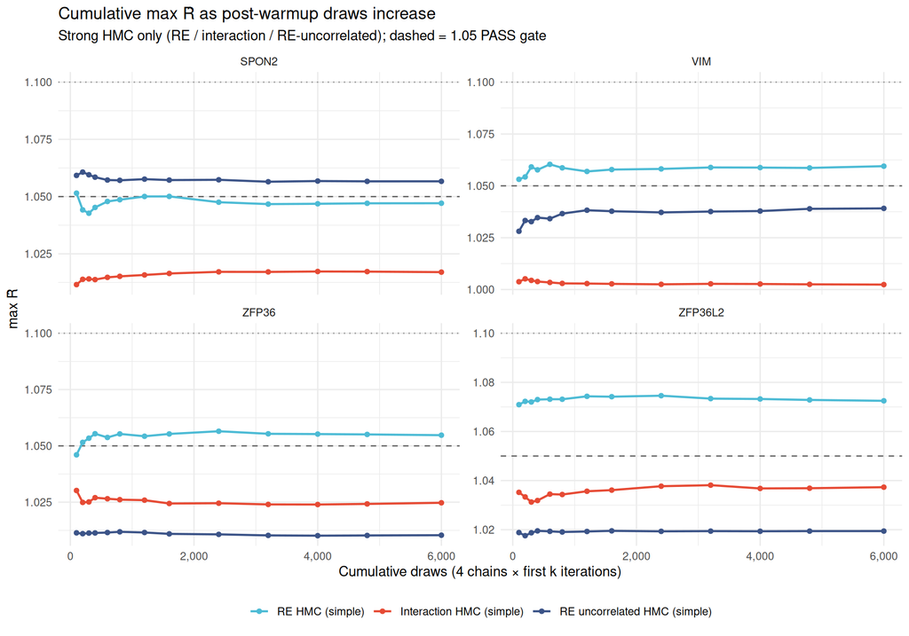

```r
ggplot(stab_curves, aes(x = n_draws, y = max_rhat, colour = formula)) +
  geom_hline(yintercept = 1.05, linetype = 2, colour = "grey40") +
  geom_hline(yintercept = 1.1, linetype = 3, colour = "grey60") +
  geom_line(linewidth = 0.8) +
  geom_point(size = 1.4) +
  facet_wrap(~ gene, scales = "free_y") +
  scale_colour_manual(values = fill_vals, drop = TRUE) +
  scale_x_continuous(labels = label_comma()) +
  labs(
    title = "Cumulative max R̂ as post-warmup draws increase",
    subtitle = "Strong HMC only (RE / interaction / RE-uncorrelated); dashed = 1.05 PASS gate",
    x = "Cumulative draws (4 chains × first k iterations)",
    y = "max R̂",
    colour = NULL
  ) +
  theme(legend.position = "bottom")
```

## Trace: baseline μ vs draws

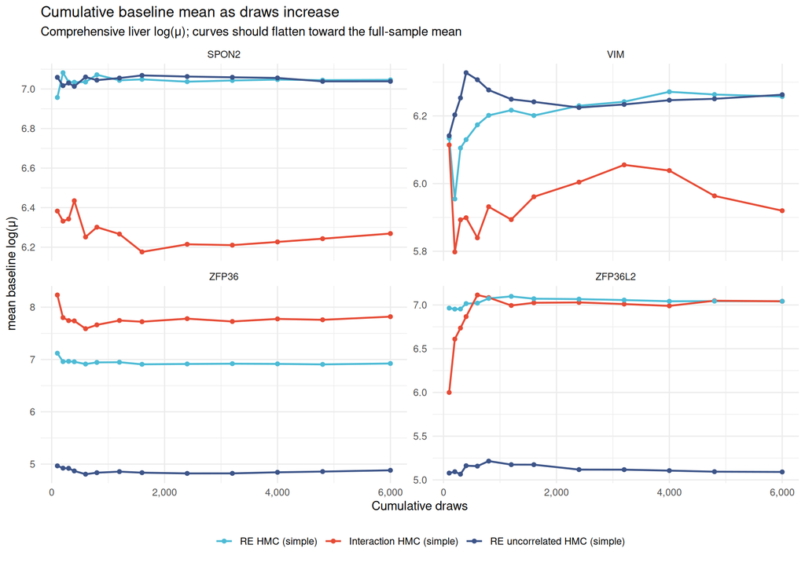

```r
ggplot(stab_curves, aes(x = n_draws, y = baseline_mean, colour = formula)) +
  geom_line(linewidth = 0.8) +
  geom_point(size = 1.4) +
  facet_wrap(~ gene, scales = "free_y") +
  scale_colour_manual(values = fill_vals, drop = TRUE) +
  scale_x_continuous(labels = label_comma()) +
  labs(
    title = "Cumulative baseline mean as draws increase",
    subtitle = "Comprehensive liver log(μ); curves should flatten toward the full-sample mean",
    x = "Cumulative draws",
    y = "mean baseline log(μ)",
    colour = NULL
  ) +
  theme(legend.position = "bottom")
```

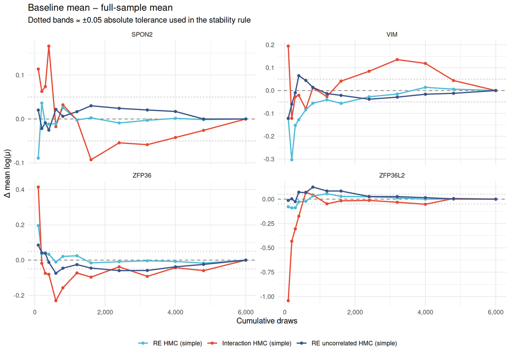

```r
ggplot(stab_curves, aes(x = n_draws, y = mean_delta, colour = formula)) +
  geom_hline(yintercept = 0, linetype = 2, colour = "grey50") +
  geom_hline(yintercept = c(-0.05, 0.05), linetype = 3, colour = "grey70") +
  geom_line(linewidth = 0.8) +
  geom_point(size = 1.4) +
  facet_wrap(~ gene, scales = "free_y") +
  scale_colour_manual(values = fill_vals, drop = TRUE) +
  scale_x_continuous(labels = label_comma()) +
  labs(
    title = "Baseline mean − full-sample mean",
    subtitle = "Dotted bands ≈ ±0.05 absolute tolerance used in the stability rule",
    x = "Cumulative draws",
    y = "Δ mean log(μ)",
    colour = NULL
  ) +
  theme(legend.position = "bottom")
```

## Trace: baseline SD vs draws

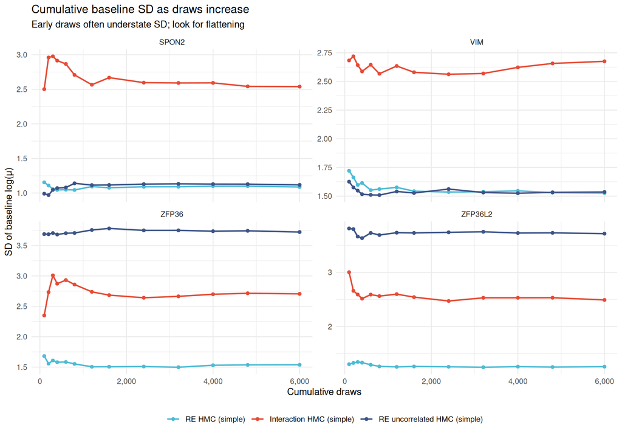

```r
ggplot(stab_curves, aes(x = n_draws, y = baseline_sd, colour = formula)) +
  geom_line(linewidth = 0.8) +
  geom_point(size = 1.4) +
  facet_wrap(~ gene, scales = "free_y") +
  scale_colour_manual(values = fill_vals, drop = TRUE) +
  scale_x_continuous(labels = label_comma()) +
  labs(
    title = "Cumulative baseline SD as draws increase",
    subtitle = "Early draws often understate SD; look for flattening",
    x = "Cumulative draws",
    y = "SD of baseline log(μ)",
    colour = NULL
  ) +
  theme(legend.position = "bottom")
```

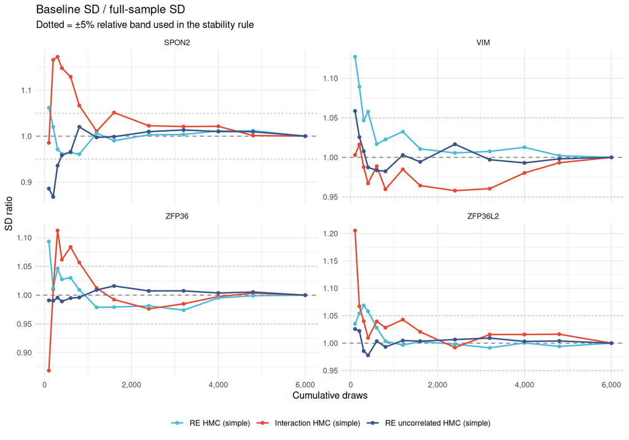

```r
ggplot(stab_curves, aes(x = n_draws, y = sd_ratio, colour = formula)) +
  geom_hline(yintercept = 1, linetype = 2, colour = "grey50") +
  geom_hline(yintercept = c(0.95, 1.05), linetype = 3, colour = "grey70") +
  geom_line(linewidth = 0.8) +
  geom_point(size = 1.4) +
  facet_wrap(~ gene, scales = "free_y") +
  scale_colour_manual(values = fill_vals, drop = TRUE) +
  scale_x_continuous(labels = label_comma()) +
  labs(
    title = "Baseline SD / full-sample SD",
    subtitle = "Dotted = ±5% relative band used in the stability rule",
    x = "Cumulative draws",
    y = "SD ratio",
    colour = NULL
  ) +
  theme(legend.position = "bottom")
```

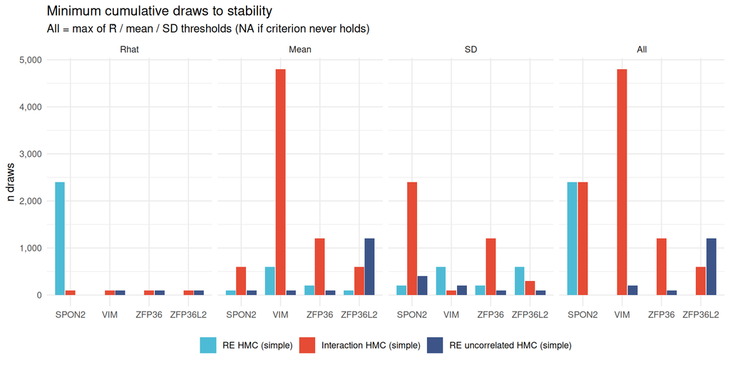

```r
thr_long <- stab_thresholds |>
  select(
    gene, formula,
    Rhat = n_draws_rhat_stable,
    Mean = n_draws_mean_stable,
    SD = n_draws_sd_stable,
    All = n_draws_all_stable
  ) |>
  pivot_longer(c(Rhat, Mean, SD, All), names_to = "metric", values_to = "n_draws") |>
  mutate(metric = factor(metric, levels = c("Rhat", "Mean", "SD", "All")))

ggplot(thr_long, aes(x = gene, y = n_draws, fill = formula)) +
  geom_col(position = position_dodge(width = 0.8), width = 0.75) +
  facet_wrap(~ metric, nrow = 1) +
  scale_fill_manual(values = fill_vals, drop = TRUE) +
  scale_y_continuous(labels = label_comma()) +
  labs(
    title = "Minimum cumulative draws to stability",
    subtitle = "All = max of R̂ / mean / SD thresholds (NA if criterion never holds)",
    x = NULL, y = "n draws", fill = NULL
  ) +
  theme(legend.position = "bottom")
```

# Baseline posterior densities

```r
need_draws <- isTRUE(params$refresh_diagnostics) ||
  need_refresh ||
  !file.exists(draws_path)

if (need_draws) {
  message("Collecting baseline draws (includes Pathfinder) ...")
  draws_df <- collect_strong_baseline_draws(
    strong_out_dir = params$strong_out_dir,
    case_dir = params$case_dir,
    model_store_root = params$model_store_root,
    target_cell_type = params$target_cell_type,
    n_draws = params$n_baseline_draws,
    cache_rds = draws_path
  )
} else {
  draws_df <- readRDS(draws_path)
}

draws_labelled <- draws_df |>
  mutate(
    formula = factor(
      recode(model, !!!formula_labels),
      levels = unname(formula_labels)
    ),
    is_pathfinder = str_detect(model, "^pathfinder")
  )
```

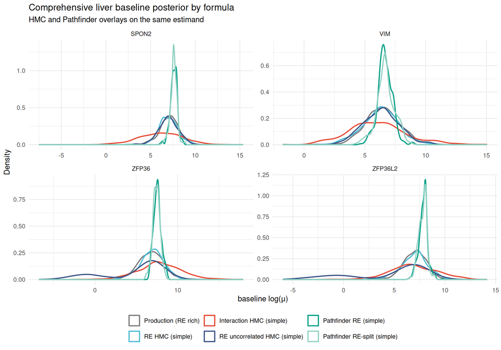

```r
ggplot(draws_labelled, aes(x = baseline_log_mu, colour = formula)) +
  geom_density(linewidth = 0.8) +
  facet_wrap(~ gene, scales = "free") +
  scale_colour_manual(values = fill_vals, drop = FALSE) +
  labs(
    title = "Comprehensive liver baseline posterior by formula",
    subtitle = "HMC and Pathfinder overlays on the same estimand",
    x = "baseline log(μ)", y = "Density", colour = NULL
  ) +
  theme(legend.position = "bottom")
```

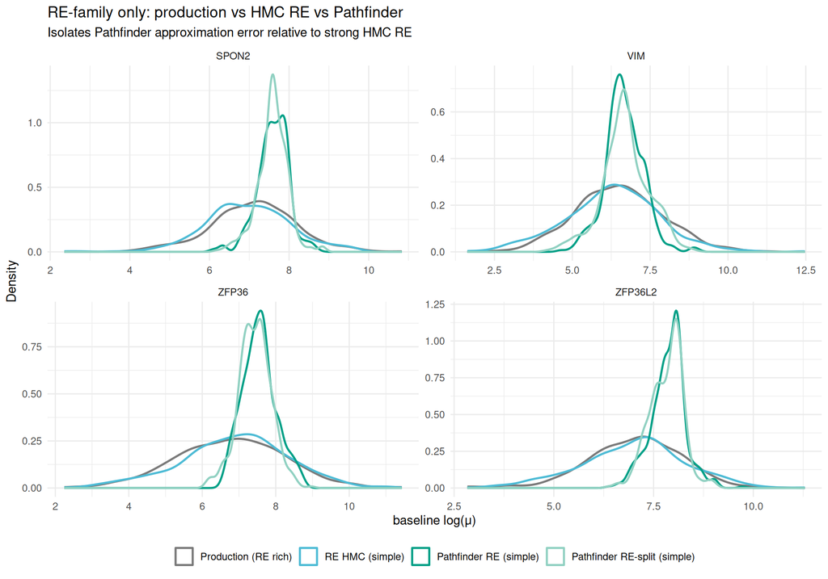

```r
re_family <- draws_labelled |>
  filter(model %in% c("production", "re", "pathfinder_re", "pathfinder_re_split"))

ggplot(re_family, aes(x = baseline_log_mu, colour = formula)) +
  geom_density(linewidth = 0.85) +
  facet_wrap(~ gene, scales = "free") +
  scale_colour_manual(values = fill_vals, drop = TRUE) +
  labs(
    title = "RE-family only: production vs HMC RE vs Pathfinder",
    subtitle = "Isolates Pathfinder approximation error relative to strong HMC RE",
    x = "baseline log(μ)", y = "Density", colour = NULL
  ) +
  theme(legend.position = "bottom")
```

# Settings used

```r
diag_view |>
  distinct(
    formula, engine, gene, source, algorithm,
    chains, warmup, iter, n_draws, adapt_delta, max_treedepth, seed
  ) |>
  arrange(formula, gene)
```

| formula | engine | gene | source | algorithm | chains | warmup | iter | n_draws | adapt_delta | max_treedepth | seed |
| --- | --- | --- | --- | --- | --- | --- | --- | --- | --- | --- | --- |
| Production (RE rich) | HMC | SPON2 | production_store | sampling | 2 | 400 | 600 | 400 | NA | NA | 1190335185 |
| Production (RE rich) | HMC | VIM | production_store | sampling | 2 | 400 | 600 | 400 | NA | NA | 1458080934 |
| Production (RE rich) | HMC | ZFP36 | production_store | sampling | 2 | 400 | 600 | 400 | NA | NA | 1143613005 |
| Production (RE rich) | HMC | ZFP36L2 | production_store | sampling | 2 | 400 | 600 | 400 | NA | NA | 885402598 |
| RE HMC (simple) | HMC | SPON2 | local_rds | sampling | 4 | 1500 | 3000 | 6000 | 0.95 | 12 | 42 |
| RE HMC (simple) | HMC | VIM | local_rds | sampling | 4 | 1500 | 3000 | 6000 | 0.95 | 12 | 42 |
| RE HMC (simple) | HMC | ZFP36 | local_rds | sampling | 4 | 1500 | 3000 | 6000 | 0.95 | 12 | 42 |
| RE HMC (simple) | HMC | ZFP36L2 | local_rds | sampling | 4 | 1500 | 3000 | 6000 | 0.95 | 12 | 42 |
| Interaction HMC (simple) | HMC | SPON2 | local_rds | sampling | 4 | 1500 | 3000 | 6000 | 0.95 | 12 | 42 |
| Interaction HMC (simple) | HMC | VIM | local_rds | sampling | 4 | 1500 | 3000 | 6000 | 0.95 | 12 | 42 |

[output cut: 14 more lines]

- **Production HMC:** atlas `V1_nk` defaults (typically 2 × 400/600).
- **Strong HMC:** 4 chains × 1500 warmup / 3000 iter, `adapt_delta = 0.95`, `max_treedepth = 12`, 4 × 8 threads.
- **Pathfinder:** CPU dense, `opencl = NULL`, `sparse = FALSE`, `num_paths = 50`, `single_path_draws = 120` (target 6000 draws), `threads = 8`, `psis_resample = FALSE`.

# Interpretation

```r
n_pass <- sum(diag_view$gate == "PASS")
n_warn <- sum(diag_view$gate == "WARN")
n_fail <- sum(diag_view$gate == "FAIL")
n_pf <- sum(diag_view$is_pathfinder)

mean_sd <- diag_view |>
  group_by(formula) |>
  summarise(mean_sd = mean(baseline_sd, na.rm = TRUE), .groups = "drop") |>
  arrange(mean_sd)

best_sd <- mean_sd$formula[1]
worst_sd <- mean_sd$formula[nrow(mean_sd)]

pf_shift <- diag_view |>
  filter(model %in% c("re", "pathfinder_re")) |>
  select(gene, model, baseline_mean) |>
  pivot_wider(names_from = model, values_from = baseline_mean) |>
  mutate(abs_shift = abs(pathfinder_re - re))

stab_ok <- stab_thresholds |> filter(!is.na(n_draws_all_stable))
stab_note <- if (nrow(stab_ok)) {
  glue(
    " Strong-HMC joint draw-stability median = **{median(stab_ok$n_draws_all_stable)}** ",
    "(of {nrow(stab_ok)}/{nrow(stab_thresholds)} fits)."
  )
} else {
  " Strong-HMC joint draw-stability thresholds were not identified under current tolerances."
}

cat(glue(
  "Across {nrow(diag_view)} gene × formula cells ({n_pf} Pathfinder): ",
  "**{n_pass} PASS**, **{n_warn} WARN**, **{n_fail} FAIL**. ",
  "Tightest mean baseline SD: **{best_sd}** ({round(mean_sd$mean_sd[1], 3)}); ",
  "widest: **{worst_sd}** ({round(mean_sd$mean_sd[nrow(mean_sd)], 3)}). ",
  "Median |Pathfinder RE − HMC RE| baseline mean shift: ",
  "**{round(median(pf_shift$abs_shift, na.rm = TRUE), 3)}** log units.",
  "{stab_note}"
))
```

Across 24 gene × formula cells (8 Pathfinder): **8 PASS**, **14 WARN**, **2 FAIL**. Tightest mean baseline SD: **Pathfinder RE (simple)** (0.457); widest: **RE uncorrelated HMC (simple)** (2.539). Median |Pathfinder RE − HMC RE| baseline mean shift: **0.603** log units. Strong-HMC joint draw-stability median = **1200** (of 8/12 fits).

**How to read Pathfinder in this report**

1. **Convergence** — do not treat Pathfinder R̂ like HMC; use the Pathfinder-specific gate and compare baselines to the strong HMC RE reference.
2. **Baseline mean** — Pathfinder is useful if it tracks HMC RE closely (small `delta_pf_re`); large shifts mean the approximation is not yet a drop-in.
3. **Baseline SD** — Pathfinder can understate or overstate uncertainty; prefer HMC SD for proximity scores unless Pathfinder SD is validated gene-wise.
4. **RE-split** — ask whether splitting ethnicity slopes buys speed/stability without moving the liver baseline relative to Pathfinder original RE.

**How to read HMC draw stability**

1. Curves use **prefix draws** (first $k$ iterations × all chains), not random subsets — early R̂ can look worse than the full run.
2. Prefer the **joint** threshold (`n_draws_all_stable`) over single metrics; SD often stabilises later than the mean.
3. If the joint threshold is near 6000, the current strong-HMC budget is necessary; if it is much lower, shorter runs may still be adequate for baseline summaries (not necessarily for all parameters).

# Saved artefacts

| File | Description |
| --- | --- |
| /home/a1237163/lab/chen/posteriorHCA/dev/Jie_HCC/data/processed/re_vs_interaction_strong/`fit_*.rds` | Strong HMC fits |
| /home/a1237163/lab/chen/posteriorHCA/dev/Jie_HCC/data/processed/re_vs_interaction_strong/`fit_pathfinder_*.rds` | Pathfinder RE / RE-split |
| /home/a1237163/lab/chen/posteriorHCA/dev/Jie_HCC/data/processed/re_vs_interaction_strong/formula_comparison_diagnostics.csv | Cached diagnostics (auto-refreshes when new models appear) |
| /home/a1237163/lab/chen/posteriorHCA/dev/Jie_HCC/data/processed/re_vs_interaction_strong/formula_comparison_baseline_draws.rds | Cached baseline draws |
| /home/a1237163/lab/chen/posteriorHCA/dev/Jie_HCC/data/processed/re_vs_interaction_strong/hmc_draw_stability.rds | Cached HMC cumulative draw-stability curves + thresholds |
| Production | `V1_nk` `estimates_chunk_*` |
| Pathfinder store | `/hpcfs/.../re_vs_interaction_pathfinder/_targets` |